# MA 350 Final: EpiModel Package

Sam, Jett, Matt, and Jesse

# Install Packages

```r
#install.packages("EpiModel")
library(EpiModel)
```

# Basic SI Model Tutorial

```r
param <- param.dcm(inf.prob = 0.2, act.rate= 0.25) # parameters
init <- init.dcm(s.num = 500, i.num = 1) # collects initial conditions
control <- control.dcm(type="SI", nsteps = 500) # collects structural model controls

model <-dcm(param,init,control) # run the model
model
```

```
EpiModel Simulation
=======================
Model class: dcm

Simulation Summary
-----------------------
Model type: SI
No. runs: 1
No. time steps: 500
No. groups: 1

Model Parameters
-----------------------
inf.prob = 0.2
act.rate = 0.25

Model Output
-----------------------
Variables: s.num i.num si.flow num
```

two compartments and one flow are available. Compartments are discrete disease states and flows are the transitions between states. The i.num compartment is the size of the infected population at each of the time steps. si.flow is the number of people movng from S to I at each time step. i.num is disease prevalence and si.flow is disease incidence.

## Plot

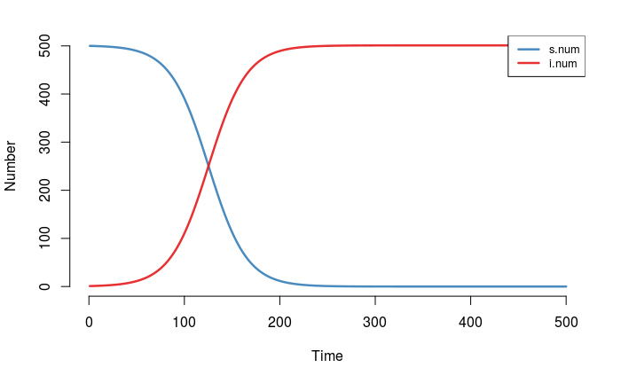

```r
plot(model)
```

## Summary

```r
summary(model, at=150)
```

```
EpiModel Summary
=======================
Model class: dcm

Simulation Summary
-----------------------
Model type: SI
No. runs: 1
No. time steps:
No. groups: 1

Model Statistics
------------------------------
Time: 150    Run: 1
------------------------------
                n    pct
Suscept.  112.845  0.225
Infect.   388.155  0.775
Total     501.000  1.000
S -> I      4.311     NA
------------------------------
```

Disease incidence is 4.31 new infections

# SIR Model with Demography Tutorial

## Model

```r
param.sir <- param.dcm(inf.prob = 0.2, act.rate=1, rec.rate=1/20, a.rate = 1/95,ds.rate=1/100,di.rate=1/80,dr.rate = 1/100)

init.sir <- init.dcm(s.num = 1000, i.num = 1, r.num = 0)
control.sir <- control.dcm(type="SIR", nsteps = 500, dt=0.5)

model.sir <- dcm(param.sir,init.sir,control.sir)
model.sir
```

```
EpiModel Simulation
=======================
Model class: dcm

Simulation Summary
-----------------------
Model type: SIR
No. runs: 1
No. time steps: 500
No. groups: 1

Model Parameters
-----------------------
inf.prob = 0.2
act.rate = 1
rec.rate = 0.05
a.rate = 0.01052632
ds.rate = 0.01
di.rate = 0.0125
dr.rate = 0.01

Model Output
-----------------------
Variables: s.num i.num r.num si.flow ir.flow a.flow
ds.flow di.flow dr.flow num
```

## Plot

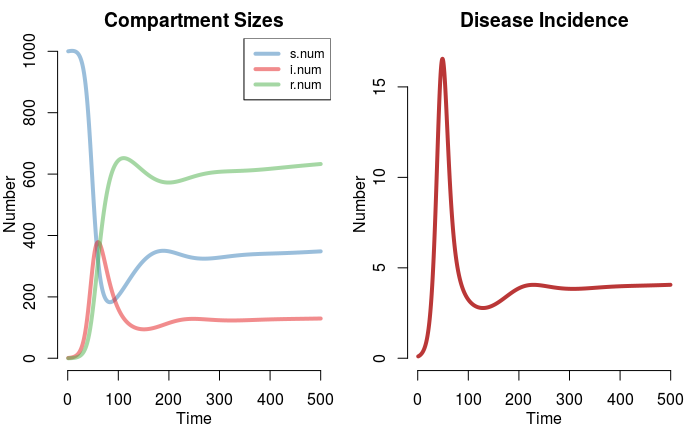

```r
par(mar = c(3.2,3,2,1), mgp=c(2,1,0), mfrow=c(1,2))
plot(model.sir, popfrac = FALSE, alpha = 0.5, lwd = 4, main= "Compartment Sizes")
plot(model.sir, y= "si.flow", lwd = 4, col = "firebrick", main = "Disease Incidence", legend="n")
```

## Summaries

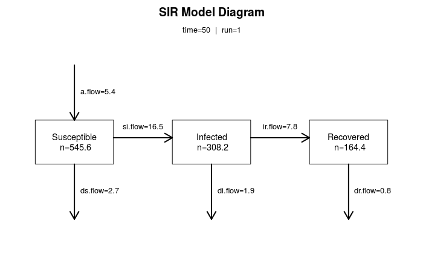

```r
par(mfrow = c(1,1))
comp_plot(model.sir, at= 50, digits=1)
```

# Basic ICMs Tutorial

## SI Model Stochasticity

```r
param.si.icm <- param.icm(inf.prob = 0.2, act.rate = 1, rec.rate = 1/20)
init.si.icm <- init.icm(s.num = 500, i.num = 1, r.num = 0)
control.si.icm <- control.icm(type="SIR", nsims = 10 ,nsteps = 300)
model.si.icm <- icm(param.si.icm,init.si.icm, control.si.icm)
model.si.icm
```

```
EpiModel Simulation
=======================
Model class: icm

Simulation Summary
-----------------------
Model type: SIR
No. simulations: 10
No. time steps: 300
No. groups: 1

Model Parameters
-----------------------
inf.prob = 0.2
act.rate = 1
rec.rate = 0.05

Model Output
-----------------------
Variables: s.num i.num num r.num si.flow ir.flow
```

## Summaries

```r
summary(model.si.icm, at= 125)
```

```
EpiModel Summary
=======================
Model class: icm

Simulation Details
-----------------------
Model type: SIR
No. simulations: 10
No. time steps: 300
No. groups: 1

Model Statistics
------------------------------
Time: 125
------------------------------
           mean       sd    pct
Suscept.  109.4  205.887  0.218
Infect.     9.5    6.169  0.019
Recov.    382.1  200.913  0.763
Total     501.0    0.000  1.000
S -> I      0.1    0.316     NA
I -> R      0.3    0.675     NA
------------------------------
```

```r
head(as.data.frame(model.si.icm, out="mean"))
```

|  | time | s.num | i.num | num | r.num | si.flow | ir.flow |
| --- | --- | --- | --- | --- | --- | --- | --- |
| 1 | 1 | 500.0 | 1.0 | 501 | 0.0 | 0.0 | 0.0 |
| 2 | 2 | 499.7 | 1.1 | 501 | 0.2 | 0.3 | 0.2 |
| 3 | 3 | 499.4 | 1.4 | 501 | 0.2 | 0.3 | 0.0 |
| 4 | 4 | 499.0 | 1.8 | 501 | 0.2 | 0.4 | 0.0 |
| 5 | 5 | 498.6 | 2.0 | 501 | 0.4 | 0.4 | 0.2 |
| 6 | 6 | 497.9 | 2.5 | 501 | 0.6 | 0.7 | 0.2 |

First six time points.

```r
tail(as.data.frame(model.si.icm, out="vals", sim=1))
```

|  | sim | time | s.num | i.num | num | r.num | si.flow | ir.flow |
| --- | --- | --- | --- | --- | --- | --- | --- | --- |
| 295 | 1 | 295 | 14 | 0 | 501 | 487 | 0 | 0 |
| 296 | 1 | 296 | 14 | 0 | 501 | 487 | 0 | 0 |
| 297 | 1 | 297 | 14 | 0 | 501 | 487 | 0 | 0 |
| 298 | 1 | 298 | 14 | 0 | 501 | 487 | 0 | 0 |
| 299 | 1 | 299 | 14 | 0 | 501 | 487 | 0 | 0 |
| 300 | 1 | 300 | 14 | 0 | 501 | 487 | 0 | 0 |

Last six time points.

## Plotting

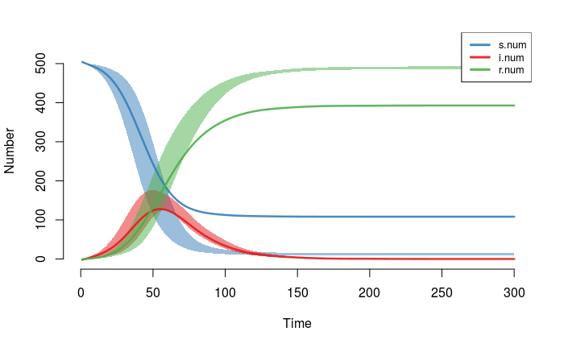

```r
plot(model.si.icm)
```

Plot of all three compartments.

# Problem 4: Investigating Simulated Outbreaks

## DCM

### Model

```r
param.ny <- param.dcm(inf.prob = 0.7, act.rate=2.2, rec.rate=1/14, a.rate = 0.014,ds.rate=0, di.rate=0.2, dr.rate = 0)


init.ny <- init.dcm(s.num = 8399000, i.num = 1, r.num = 0)
control.ny <- control.dcm(type="SIR", nsteps = 500, dt=0.5)

model.ny <- dcm(param.ny,init.ny,control.ny)
model.ny
```

```
EpiModel Simulation
=======================
Model class: dcm

Simulation Summary
-----------------------
Model type: SIR
No. runs: 1
No. time steps: 500
No. groups: 1

Model Parameters
-----------------------
inf.prob = 0.7
act.rate = 2.2
rec.rate = 0.07142857
a.rate = 0.014
ds.rate = 0
di.rate = 0.2
dr.rate = 0

Model Output
-----------------------
Variables: s.num i.num r.num si.flow ir.flow a.flow
ds.flow di.flow dr.flow num
```

DCM model built using rates and initial conditions.

### Plot

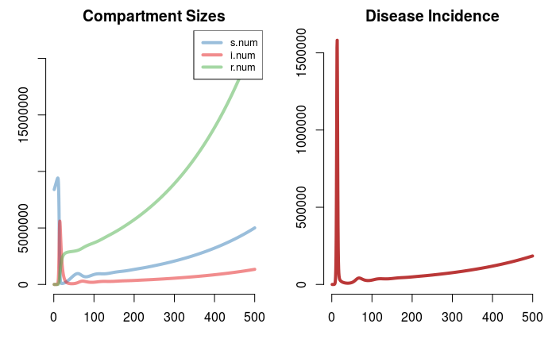

```r
par(mar = c(3.2,3,2,1), mgp=c(3,1,0), mfrow=c(1,2))
plot(model.ny, popfrac = FALSE, alpha = 0.5, lwd = 4, main= "Compartment Sizes")

plot(model.ny, y = "si.flow", lwd = 4, col = "firebrick", main = "Disease Incidence", legend="n")
```

Plot of the three compartments.

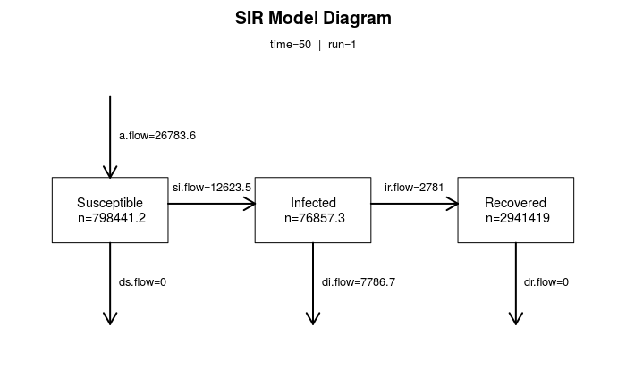

```r
par(mfrow = c(1,1))
comp_plot(model.ny, at= 50, digits=1)
```

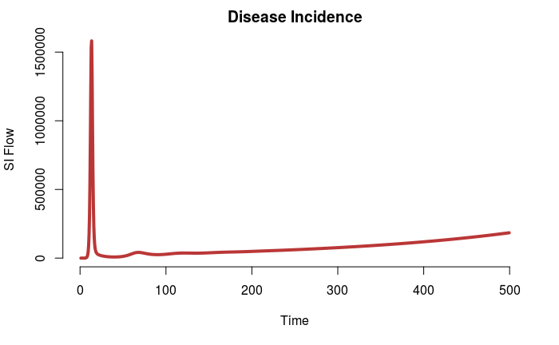

```r
plot(model.ny, y= "si.flow", lwd = 4, col = "firebrick", main = "Disease Incidence", legend="n", ylab="SI Flow")
```

Plot of disease incidence, S -> I

```r
summary(model.ny, at= 15)
```

```
EpiModel Summary
=======================
Model class: dcm

Simulation Summary
-----------------------
Model type: SIR
No. runs: 1
No. time steps:
No. groups: 1

Model Statistics
------------------------------
Time: 15     Run: 1
------------------------------
                         n    pct
Suscept.        1436354.99  0.183
Infect.         5601918.95  0.712
Recov.           825240.67  0.105
Total           7863514.61  1.000
S -> I           630604.05     NA
I -> R           198708.82     NA
Arrival ->        53279.83     NA
S Departure ->        0.00     NA
I Departure ->   556384.70     NA
R Departure ->        0.00     NA
------------------------------
```

The total number of individuals in each compartment at a given time. Here, at time 15.

# ICM

## Model

```r
set.seed(1)
param.icm.ny <- param.icm(inf.prob = 0.7,act.rate=2.2, rec.rate=1/14, a.rate = 0.014,ds.rate=0,di.rate=0.2,dr.rate = 0)
init.icm.ny <- init.icm(s.num = 10000, i.num = 1, r.num = 0)
control.icm.ny <- control.icm(type="SIR", nsims = 5,nsteps = 150)

model.icm.ny <- icm(param.icm.ny,init.icm.ny, control.icm.ny)
model.icm.ny
```

```
EpiModel Simulation
=======================
Model class: icm

Simulation Summary
-----------------------
Model type: SIR
No. simulations: 5
No. time steps: 150
No. groups: 1

Model Parameters
-----------------------
inf.prob = 0.7
act.rate = 2.2
rec.rate = 0.07142857
a.rate = 0.014
ds.rate = 0
di.rate = 0.2
dr.rate = 0

Model Output
-----------------------
Variables: s.num i.num num r.num si.flow ir.flow ds.flow
di.flow dr.flow a.flow
```

ICM model simulated 5 times with a the number of susceptibles set to 10000.

## Plot

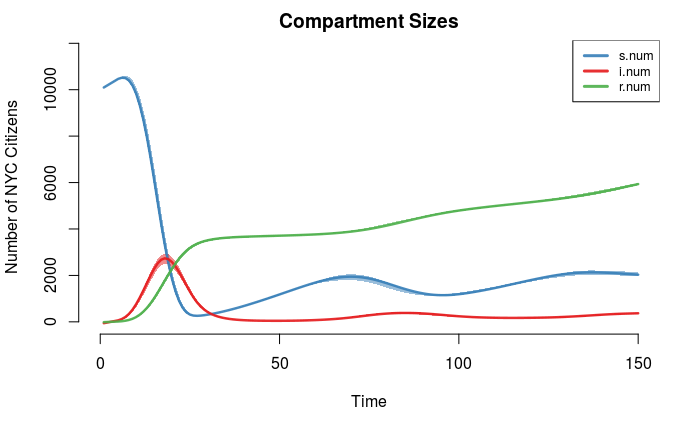

```r
plot(model.icm.ny, xlab="Time",ylab= "Number of NYC Citizens", main="Compartment Sizes")
```

Plot of the ICM model compartments.

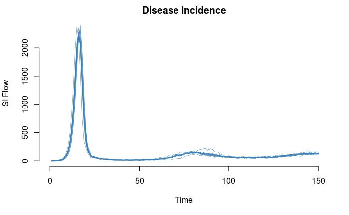

```r
plot(model.icm.ny, y= "si.flow", sim.lines=TRUE, mean.smooth = FALSE, qnts.smooth = FALSE, main = "Disease Incidence", legend="n", ylab="SI Flow")
```

Plot of the disease incidence for the ICM model.

## Summary

```r
summary(model.icm.ny, at=17) # infected peaks at time 17
```

```
EpiModel Summary
=======================
Model class: icm

Simulation Details
-----------------------
Model type: SIR
No. simulations: 5
No. time steps: 150
No. groups: 1

Model Statistics
------------------------------
Time: 17
------------------------------
                  mean        sd    pct
Suscept.        2778.8  1069.548  0.324
Infect.         4344.4   155.127  0.506
Recov.          1457.2   276.362  0.170
Total           8580.4   702.611  1.000
S -> I          2091.4   342.944     NA
I -> R           412.4    23.405     NA
Arrival ->       135.6    21.801     NA
S Departure ->     0.0     0.000     NA
I Departure ->  1074.2    25.054     NA
R Departure ->     0.0     0.000     NA
------------------------------
```

Summary of the mean, standard deviation, and percent per compartment for ICM at time 17 (the peak).

```r
summary(model.icm.ny, at=150)
```

```
EpiModel Summary
=======================
Model class: icm

Simulation Details
-----------------------
Model type: SIR
No. simulations: 5
No. time steps: 150
No. groups: 1

Model Statistics
------------------------------
Time: 150
------------------------------
                  mean       sd    pct
Suscept.        2031.2  162.159  0.244
Infect.          362.2   39.884  0.043
Recov.          5936.0   83.346  0.713
Total           8329.4   86.448  1.000
S -> I           126.0   13.472     NA
I -> R            34.2    6.611     NA
Arrival ->       119.6   13.502     NA
S Departure ->     0.0    0.000     NA
I Departure ->    88.0   16.823     NA
R Departure ->     0.0    0.000     NA
------------------------------
```

Summary of the mean, standard deviation, and percent per compartment for ICM at time 150 (the last day).

```r
tail(as.data.frame(model.icm.ny, out="mean"))
```

|  | time | s.num | i.num | num | r.num | si.flow | ir.flow | ds.flow | di.flow | dr.flow | a.flow |
| --- | --- | --- | --- | --- | --- | --- | --- | --- | --- | --- | --- |
| 145 | 145 | 2081.0 | 365.6 | 8203.8 | 5757.2 | 136.0 | 33.2 | 0 | 86.6 | 0 | 119.6 |
| 146 | 146 | 2070.8 | 361.4 | 8228.8 | 5796.6 | 129.4 | 39.4 | 0 | 94.2 | 0 | 119.2 |
| 147 | 147 | 2064.8 | 354.2 | 8252.4 | 5833.4 | 124.4 | 36.8 | 0 | 94.8 | 0 | 118.4 |
| 148 | 148 | 2055.0 | 362.8 | 8282.8 | 5865.0 | 129.8 | 31.6 | 0 | 89.6 | 0 | 120.0 |
| 149 | 149 | 2037.6 | 358.4 | 8297.8 | 5901.8 | 131.6 | 36.8 | 0 | 99.2 | 0 | 114.2 |
| 150 | 150 | 2031.2 | 362.2 | 8329.4 | 5936.0 | 126.0 | 34.2 | 0 | 88.0 | 0 | 119.6 |

The last time steps of the ICM model. Used to see how the pandemic subsided.

# Problem 5

## Low infection probability

```r
set.seed(1)
param.icm.ny.2 <- param.icm(inf.prob = 0.2,act.rate=2.2, rec.rate=1/14, a.rate = 0.014,ds.rate=0,di.rate=0.2,dr.rate = 0)
init.icm.ny.2 <- init.icm(s.num = 10000, i.num = 1, r.num = 0)
control.icm.ny.2 <- control.icm(type="SIR", nsims = 5,nsteps = 150)

model.icm.ny.2 <- icm(param.icm.ny.2,init.icm.ny.2, control.icm.ny.2)
model.icm.ny.2
```

```
EpiModel Simulation
=======================
Model class: icm

Simulation Summary
-----------------------
Model type: SIR
No. simulations: 5
No. time steps: 150
No. groups: 1

Model Parameters
-----------------------
inf.prob = 0.2
act.rate = 2.2
rec.rate = 0.07142857
a.rate = 0.014
ds.rate = 0
di.rate = 0.2
dr.rate = 0

Model Output
-----------------------
Variables: s.num i.num num r.num si.flow ir.flow ds.flow
di.flow dr.flow a.flow
```

Change the infection probability parameter to 0.2 to see how the model changes.

### Low infection probability plot

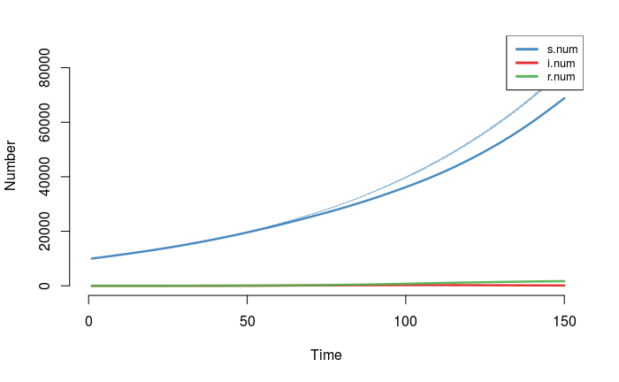

```r
plot(model.icm.ny.2)
```

Plot of the model using low infection probability.

### Low infection probability summary

```r
summary(model.icm.ny.2, at=100) # infected peaks at 100
```

```
EpiModel Summary
=======================
Model class: icm

Simulation Details
-----------------------
Model type: SIR
No. simulations: 5
No. time steps: 150
No. groups: 1

Model Statistics
------------------------------
Time: 100
------------------------------
                   mean        sd    pct
Suscept.        36174.2  8273.699  0.973
Infect.           258.0   576.906  0.007
Recov.            742.4  1656.144  0.020
Total           37174.6  6042.900  1.000
S -> I             86.2   192.749     NA
I -> R             23.0    51.430     NA
Arrival ->        515.8    75.351     NA
S Departure ->      0.0     0.000     NA
I Departure ->     59.6   133.270     NA
R Departure ->      0.0     0.000     NA
------------------------------
```

Summary of the model using low infection probability.

## High infection probability

```r
set.seed(1)
param.icm.ny.3 <- param.icm(inf.prob = 0.9,act.rate=2.2, rec.rate=1/14, a.rate = 0.014,ds.rate=0,di.rate=0.2,dr.rate = 0)
init.icm.ny.3 <- init.icm(s.num = 10000, i.num = 1, r.num = 0)
control.icm.ny.3 <- control.icm(type="SIR", nsims = 5,nsteps = 150)

model.icm.ny.3 <- icm(param.icm.ny.3,init.icm.ny.3, control.icm.ny.3)
model.icm.ny.3
```

```
EpiModel Simulation
=======================
Model class: icm

Simulation Summary
-----------------------
Model type: SIR
No. simulations: 5
No. time steps: 150
No. groups: 1

Model Parameters
-----------------------
inf.prob = 0.9
act.rate = 2.2
rec.rate = 0.07142857
a.rate = 0.014
ds.rate = 0
di.rate = 0.2
dr.rate = 0

Model Output
-----------------------
Variables: s.num i.num num r.num si.flow ir.flow ds.flow
di.flow dr.flow a.flow
```

Change the infection probability again, to be higher and see how the model changes.

### High infection probability plot

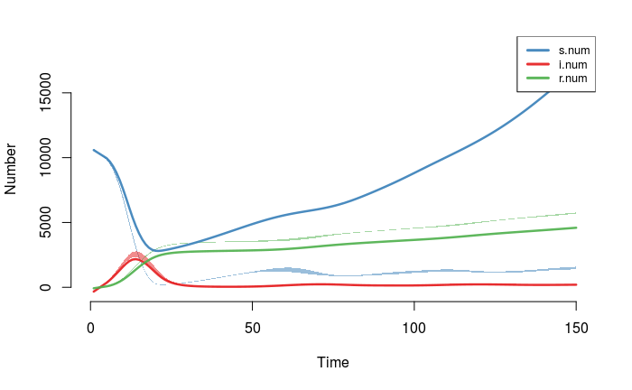

```r
plot(model.icm.ny.3)
```

Plot of the high infection probability.

### High infection probability summary

```r
summary(model.icm.ny.3, at=13)
```

```
EpiModel Summary
=======================
Model class: icm

Simulation Details
-----------------------
Model type: SIR
No. simulations: 5
No. time steps: 150
No. groups: 1

Model Statistics
------------------------------
Time: 13
------------------------------
                  mean        sd    pct
Suscept.        3722.8  4576.212  0.426
Infect.         3852.2  2159.278  0.441
Recov.          1155.8   678.156  0.132
Total           8730.8  1816.525  1.000
S -> I          1807.4  1141.105     NA
I -> R           365.8   204.573     NA
Arrival ->       134.0    21.272     NA
S Departure ->     0.0     0.000     NA
I Departure ->   974.6   546.615     NA
R Departure ->     0.0     0.000     NA
------------------------------
```

Summary of the high infection probability.

# Problem 6: Government Intervention

Change the act rate to be low, since quarantine prevents interaction. Additionally, decrease the probability of infection since quarantine reduces the risk.

```r
param.ny.intervention <- param.dcm(inf.prob = 0.4, act.rate=1, rec.rate=1/14, a.rate = 0.014,ds.rate=0,di.rate=0.2,dr.rate = 0)

init.ny.intervention <- init.dcm(s.num = 8399000, i.num = 1, r.num = 0)
control.ny.intervention <- control.dcm(type="SIR", nsteps = 200, dt=0.5)

model.ny.intervention <- dcm(param.ny.intervention,init.ny.intervention,control.ny.intervention)
model.ny.intervention
```

```
EpiModel Simulation
=======================
Model class: dcm

Simulation Summary
-----------------------
Model type: SIR
No. runs: 1
No. time steps: 200
No. groups: 1

Model Parameters
-----------------------
inf.prob = 0.4
act.rate = 1
rec.rate = 0.07142857
a.rate = 0.014
ds.rate = 0
di.rate = 0.2
dr.rate = 0

Model Output
-----------------------
Variables: s.num i.num r.num si.flow ir.flow a.flow
ds.flow di.flow dr.flow num
```

Model built with parameter estimates varied to account for government intervention.

## Plot

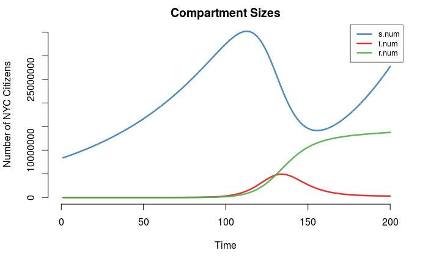

```r
plot(model.ny.intervention, ylab="Number of NYC Citizens", xlab="Time", main="Compartment Sizes")
```

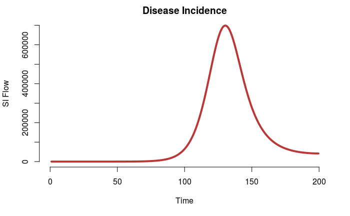

```r
plot(model.ny.intervention, y= "si.flow", lwd = 4, col = "firebrick", main = "Disease Incidence", legend="n", ylab="SI Flow")
```

Plot of the pandemic under government intervention.

## Summary

```r
summary(model.ny.intervention, at=125.5)
```

```
EpiModel Summary
=======================
Model class: dcm

Simulation Summary
-----------------------
Model type: SIR
No. runs: 1
No. time steps:
No. groups: 1

Model Statistics
------------------------------
Time: 125.5  Run: 1
------------------------------
                         n    pct
Suscept.        30433139.6  0.809
Infect.          3958064.7  0.105
Recov.           3222225.1  0.086
Total           37613429.5  1.000
S -> I            645866.6     NA
I -> R            143186.2     NA
Arrival ->        262817.1     NA
S Departure ->         0.0     NA
I Departure ->    400921.3     NA
R Departure ->         0.0     NA
------------------------------
```

```r
summary(model.ny.intervention, at=199.5)
```

```
EpiModel Summary
=======================
Model class: dcm

Simulation Summary
-----------------------
Model type: SIR
No. runs: 1
No. time steps:
No. groups: 1

Model Statistics
------------------------------
Time: 199.5  Run: 1
------------------------------
                          n    pct
Suscept.        27494429.22  0.661
Infect.           315879.48  0.008
Recov.          13769011.78  0.331
Total           41579320.48  1.000
S -> I             41764.35     NA
I -> R             11262.59     NA
Arrival ->        291965.63     NA
S Departure ->         0.00     NA
I Departure ->     31535.26     NA
R Departure ->         0.00     NA
------------------------------
```